# **Motor Car trends**

Author

Thej Ratheesh

## Introduction

The **`mtcars`** dataset, included in base R, contains data on 32 car models from the 1970s. Each row represents a car, with variables such as horsepower, weight, and miles-per-gallon (MPG).

In this brief analysis, we explore the relationship between a car’s **horsepower** and its **fuel efficiency** measured in MPG.

[**R Documentation Link**](https://www.rdocumentation.org/packages/datasets/versions/3.6.2/topics/mtcars).

|  | mpg | cyl | disp | hp | drat | wt | qsec | vs | am | gear | carb |
| --- | --- | --- | --- | --- | --- | --- | --- | --- | --- | --- | --- |
| Mazda RX4 | 21.0 | 6 | 160 | 110 | 3.90 | 2.620 | 16.46 | 0 | 1 | 4 | 4 |
| Mazda RX4 Wag | 21.0 | 6 | 160 | 110 | 3.90 | 2.875 | 17.02 | 0 | 1 | 4 | 4 |
| Datsun 710 | 22.8 | 4 | 108 | 93 | 3.85 | 2.320 | 18.61 | 1 | 1 | 4 | 1 |
| Hornet 4 Drive | 21.4 | 6 | 258 | 110 | 3.08 | 3.215 | 19.44 | 1 | 0 | 3 | 1 |
| Hornet Sportabout | 18.7 | 8 | 360 | 175 | 3.15 | 3.440 | 17.02 | 0 | 0 | 3 | 2 |
| Valiant | 18.1 | 6 | 225 | 105 | 2.76 | 3.460 | 20.22 | 1 | 0 | 3 | 1 |

## Bar Chart

The bar chart shown displays the Miles per Gallon (MPG) for each car model in the mtcars dataset.

- X-axis: Car models (e.g., Toyota Corolla, Fiat 128, Lincoln Continental).
- Y-axis: Miles per Gallon — a measure of fuel efficiency.
- The bars are sorted in descending order, meaning the most fuel-efficient cars appear on the left, and the least efficient on the right.

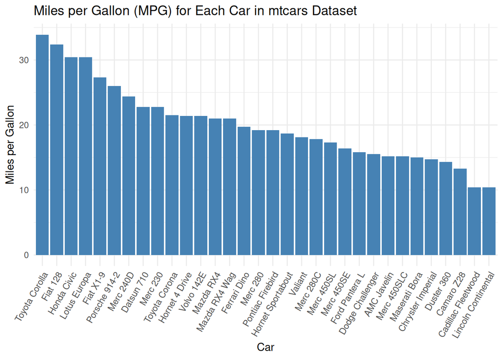

## MPG Distribution by Cylinder Count:

This graph is a boxplot that visualizes the distribution of miles per gallon (MPG) for cars with different numbers of cylinders (4, 6, and 8) in the mtcars dataset.

Each boxplot shows:

- The median MPG (thick black horizontal line inside each box).
- The interquartile range (IQR) (height of the box — middle 50% of the data).
- The whiskers extend to 1.5×IQR or to the min/max (if no outliers).
- Outliers (individual points outside whiskers) are shown as small circles (e.g., in the 8-cylinder group).

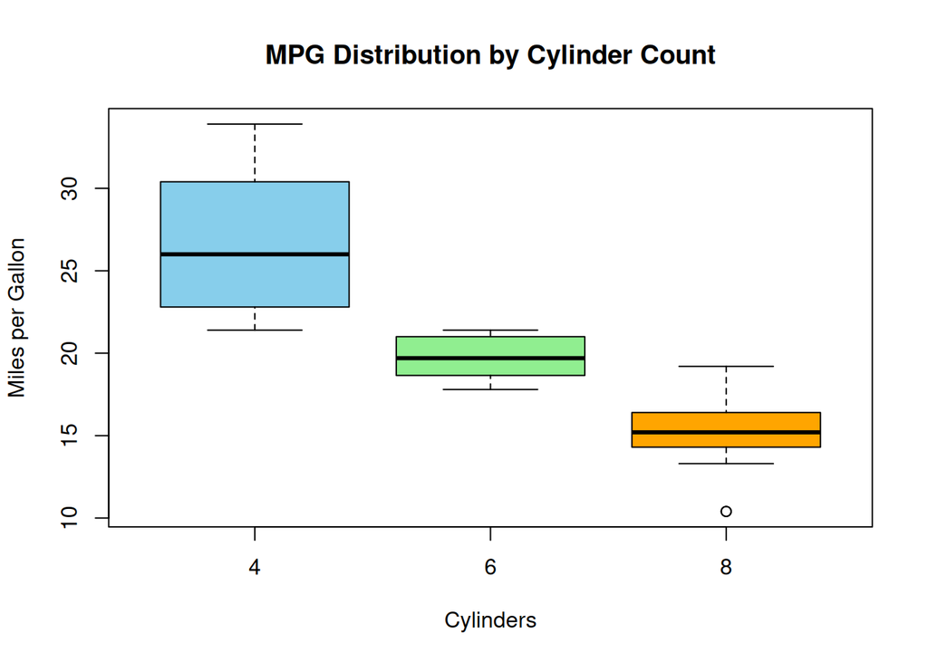

## Pairwise Scatterplot Matrix

This is a pairwise scatterplot matrix. It visualizes the relationships among four variables from the mtcars dataset:

- mpg: Miles per gallon (fuel efficiency)
- hp: Horsepower
- wt: Weight (in 1000 lbs)
- qsec: 1/4 mile time (acceleration)

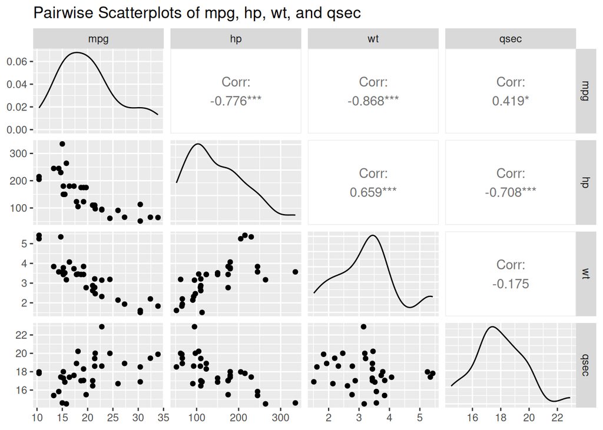

- Fuel efficiency (mpg) is most negatively affected by weight (wt) and horsepower (hp)
- Heavier and more powerful cars generally use more fuel.
- The strongest overall relationship in the data is between mpg and wt.

## Summary

From our analysis it can be examined that :

- Fuel efficiency (MPG) varies widely across car models, with compact cars like the Toyota Corolla and Fiat 128 outperforming heavier models like the Lincoln Continental.
- Cars with fewer cylinders (4 or 6) tend to have higher MPG than 8-cylinder models, as seen in the boxplot analysis.
- Pairwise correlations revealed strong negative relationships between MPG and both horsepower (-0.78) and weight (-0.87), suggesting that more powerful and heavier vehicles are less fuel efficient.
- A moderate positive correlation between MPG and qsec indicates that more efficient cars tend to have slightly slower acceleration, potentially due to smaller engines.

lighter and less powerful vehicles tend to be more fuel efficient, which is kind of the expected and practical outcome.